# Experimentação Agronômica - Exemplos

José Genivaldo do Vale Moreira

2022-07-23

# Capítulo 9: Experimentos em parcelas subdivididas

## Exemplo 9.2 (Pág. 250)

Para a obtenção da análise de vairiância de um experimento em parcelas subdivididas, vamos utilizar os dados obtidos do trabalho intitulado “Efeito de épocas de plantio sobre várias características agronômicas na sultura da soja (*Glycine max.* (L.) Merril), variedades Santa Rosa e Viçoja, em Jaboticabal, SP”, realizado por YUYAMA (1976). Foram utilizadas 8 eócas de plantio (20/10/74, 30/10/74, 10/11/74, 20/11/74, 30/11/74, 10/12/74, 20/12/74 e 30/12/74) e 2 variedades de soja (V<sub>1</sub> = Viçoja e V<sub>2</sub> = Santa Rosa). O ensaio foi montado de acordo com delineamento em parcelas subdivididas, com as épocas de plantio nas parcelas, e as variedades na subparcelas. Os resultados obtidos para a produção de grãos (t/ha), foram os seguintes:

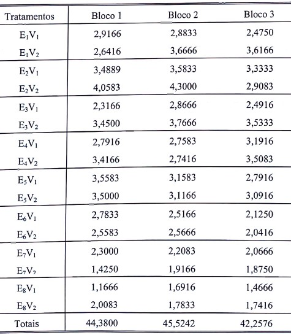

As hipóteses a serem testadas são:  
**Para o efeito das épocas** H<sub>0</sub>: As épocas de plantio não diferem entre si em relação à produção da cultura de soja.

**Para o efeito das variedades** H<sub>0</sub>: As variedades não diferem entre si em relação à produção da cultura de soja.

**Para o efeito da interação** H<sub>0</sub>: As épocas e as variedades não agem conjuntamente sobre a produção da cultura da soja.

### Carregar os dados

Carregar os dados a partir do link.

```r
dados9_2 = read.csv("https://raw.githubusercontent.com/genivaldomoreira/Analise_experimentos_agronomicos/main/Dados/exemplo9_2.csv", header = TRUE, sep = ";", dec = ".")
head(dados9_2, 8) # exibir as 8 primeiras linhas para conferir
```

```
##    epoca  variedade  bloco producao
## 1 epoca1     vicoja bloco1   2.9166
## 2 epoca1     vicoja bloco2   2.8833
## 3 epoca1     vicoja bloco3   2.4750
## 4 epoca1 santa_rosa bloco1   2.6416
## 5 epoca1 santa_rosa bloco2   3.6666
## 6 epoca1 santa_rosa bloco3   3.6166
## 7 epoca2     vicoja bloco1   3.4889
## 8 epoca2     vicoja bloco2   3.5833
```

### Análise por meio do pacote **ExpDes** e **ExpDes.pt**

OBS: Caso deseje cosultar o comando a ser executado, depois de carregar o pacote, use `help("psub2.dbc")`

```r
library(ExpDes)
library(ExpDes.pt)
psub2.dbc(dados9_2$epoca,dados9_2$variedade,
  dados9_2$bloco, dados9_2$producao, quali = c(TRUE, TRUE),
  mcomp = "tukey", fac.names = c("Época", "Variedade"),
  sigT = 0.05, sigF = 0.05)
```

```
## ------------------------------------------------------------------------
## Legenda:
## FATOR 1 (parcela):  Época
## FATOR 2 (subparcela):  Variedade
## ------------------------------------------------------------------------
##
## ------------------------------------------------------------------------
## Quadro da analise de variancia
## ------------------------------------------------------------------------
##                 GL      SQ      QM      Fc  Pr(>Fc)
## Época            7 19.0482 2.72117 18.8291    4e-06 ***
## Bloco            2  0.3434 0.17171  1.1882 0.333718
## Erro a          14  2.0233 0.14452
## Variedade        1  0.8276 0.82761  9.4997 0.007142 **
## Época*Variedade  7  2.0370 0.29100  3.3402 0.021671 *
## Erro b          16  1.3939 0.08712
## Total           47 25.6734
## ---
## Signif. codes:  0 '***' 0.001 '**' 0.01 '*' 0.05 '.' 0.1 ' ' 1
## ------------------------------------------------------------------------
## CV 1 = 13.80697 %
## CV 2 = 10.71998 %
##
##
##
## Interacao significativa: desdobrando a interacao
## ------------------------------------------------------------------------
##
## Desdobrando  Época  dentro de cada nivel de  Variedade
## ------------------------------------------------------------------------
##                                     GL        SQ       QM        Fc valor.p
## Época : Variedade santa_rosa   7.00000 12.912557 1.844651 15.926946       0
## Época : Variedade vicoja       7.00000  8.172581 1.167512 10.080441   4e-06
## Erro combinado                27.28941  3.160659 0.115820
## ------------------------------------------------------------------------
##
##
##  Época dentro de Variedade santa_rosa
## ------------------------------------------------------------------------
## Teste de Tukey
```

[output cut: 103 more lines]

```
## De acordo com o teste F, as medias desse fator sao estatisticamente iguais.
## ------------------------------------------------------------------------
##       Niveis   Medias
## 1 santa_rosa 1.738867
## 2     vicoja 2.191633
## ------------------------------------------------------------------------
##
##  Variedade dentro de Época epoca8
## ------------------------------------------------------------------------
## De acordo com o teste F, as medias desse fator sao estatisticamente iguais.
## ------------------------------------------------------------------------
##       Niveis Medias
## 1 santa_rosa 1.8444
## 2     vicoja 1.4416
## ------------------------------------------------------------------------
```

### Análise por meio do pacote **Easyanova**

```
##    epoca  variedade  bloco producao
## 1 epoca1     vicoja bloco1   2.9166
## 2 epoca1     vicoja bloco2   2.8833
## 3 epoca1     vicoja bloco3   2.4750
## 4 epoca1 santa_rosa bloco1   2.6416
## 5 epoca1 santa_rosa bloco2   3.6666
## 6 epoca1 santa_rosa bloco3   3.6166
```

Agora vamos inverter as posição das colunas que contem os dados da variedade e dos blocos. Vamos chamar o novo objeto de `dados9_2_easy`:

```r
dados9_2_easy = data.frame(dados9_2$epoca, dados9_2$bloco,dados9_2$variedade, dados9_2$producao)
colnames(dados9_2_easy) = c("epoca", "bloco", "variedade", "producao") # muda o nome das colunas
head(dados9_2_easy)
```

```
##    epoca  bloco  variedade producao
## 1 epoca1 bloco1     vicoja   2.9166
## 2 epoca1 bloco2     vicoja   2.8833
## 3 epoca1 bloco3     vicoja   2.4750
## 4 epoca1 bloco1 santa_rosa   2.6416
## 5 epoca1 bloco2 santa_rosa   3.6666
## 6 epoca1 bloco3 santa_rosa   3.6166
```

Agora é só executar o comando do pacote **Easyanova**. Caso deseje ajuda sobre o comando, carregue o pacote e depois execute o comando `help("ea2")`.

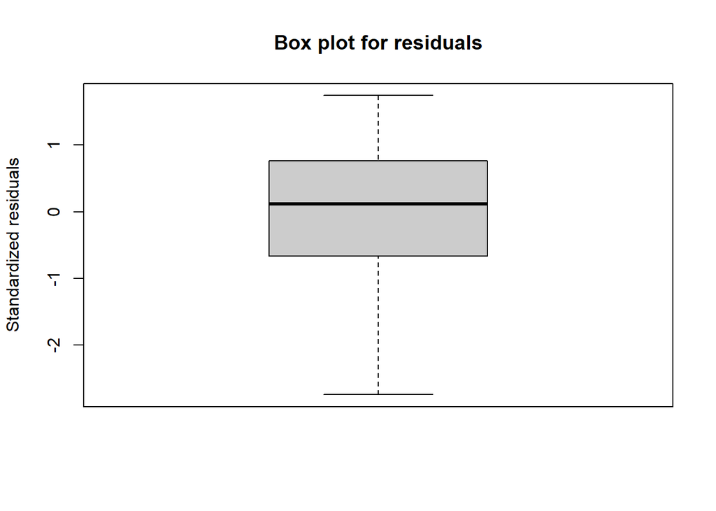

```r
library(easyanova)
ea9_2 = ea2(dados9_2_easy, design = 5, alpha = 0.05, cov = 4,
    list = FALSE, p.adjust=1, plot=1)
```

```r
ea9_2
```

```
## $`Marginal anova (Type III Sum of Squares)`
##                 numDF denDF   F-value p-value
## plot                7    14 18.829072  <.0001
## split.plot          1    16  9.499664  0.0071
## block               2    14  1.188166  0.3337
## plot:split.plot     7    16  3.340181  0.0217
##
## $`Adjusted means (plot)`
##     plot adjusted.mean standard.error tukey snk duncan  t
## 1 epoca2        3.6120         0.1552     a   a      a  a
## 2 epoca5        3.2027         0.1552    ab   a     ab ab
## 3 epoca3        3.0708         0.1552    ab   a      b  b
## 4 epoca4        3.0680         0.1552    ab   a      b  b
## 5 epoca1        3.0333         0.1552    ab   a      b  b
## 6 epoca6        2.4319         0.1552    bc   b      c  c
## 7 epoca7        1.9653         0.1552    cd  bc     cd cd
## 8 epoca8        1.6430         0.1552     d   c      d  d
##
## $`Multiple comparison test (plot)`
##               pair contrast p(tukey) p(snk) p(duncan)   p(t)
## 1  epoca2 - epoca5   0.4093   0.5921 0.0833    0.0833 0.0833
## 2  epoca2 - epoca3   0.5412   0.2839 0.0660    0.0336 0.0272
## 3  epoca2 - epoca4   0.5440   0.2788 0.1073    0.0371 0.0265
## 4  epoca2 - epoca1   0.5787   0.2208 0.1164    0.0305 0.0195
## 5  epoca2 - epoca6   1.1801   0.0019 0.0011    0.0002 0.0001
## 6  epoca2 - epoca7   1.6467   0.0001 0.0000    0.0000 0.0000
## 7  epoca2 - epoca8   1.9690   0.0000 0.0000    0.0000 0.0000
## 8  epoca5 - epoca3   0.1319   0.9983 0.5575    0.5575 0.5575
## 9  epoca5 - epoca4   0.1347   0.9980 0.8151    0.5700 0.5493
## 10 epoca5 - epoca1   0.1694   0.9921 0.8658    0.4880 0.4531
## 11 epoca5 - epoca6   0.7708   0.0515 0.0241    0.0061 0.0035
## 12 epoca5 - epoca7   1.2374   0.0012 0.0007    0.0001 0.0001
## 13 epoca5 - epoca8   1.5597   0.0001 0.0001    0.0000 0.0000
## 14 epoca3 - epoca4   0.0028   1.0000 0.9900    0.9900 0.9900
## 15 epoca3 - epoca1   0.0375   1.0000 0.9841    0.8737 0.8668
## 16 epoca3 - epoca6   0.6389   0.1434 0.0496    0.0168 0.0114
## 17 epoca3 - epoca7   1.1055   0.0034 0.0014    0.0004 0.0002
## 18 epoca3 - epoca8   1.4278   0.0003 0.0002    0.0000 0.0000
## 19 epoca4 - epoca1   0.0347   1.0000 0.8766    0.8766 0.8766
## 20 epoca4 - epoca6   0.6361   0.1464 0.0295    0.0149 0.0117
```

[output cut: 250 more lines]

```
##  1.16034715 -0.12393497 -1.03641218 -2.71561844  0.97234201  1.74327643
##           7           8           9          10          11          12
## -0.26339729 -0.33600885  0.59940614  1.06325447  1.68270692 -2.74596139
##          13          14          15          16          17          18
## -0.84329429  0.72968138  0.11361291 -0.33415193  0.14223352  0.19191841
##          19          20          21          22          23          24
## -0.69937657 -0.39750933  1.09688590  0.78842792 -1.92462317  1.13619526
##          25          26          27          28          29          30
##  1.16034872 -0.19059115 -0.96975757  0.57321409 -0.69973351  0.12651942
##          31          32          33          34          35          36
##  0.94513112 -0.26936162 -0.67576950  0.29268970  0.37023770 -0.66292740
##          37          38          39          40          41          42
##  0.64316048 -0.36333753 -0.27982295 -1.34063103  0.39340681  0.94722422
##          43          44          45          46          47          48
## -1.24610055  0.73807112  0.50802943  0.81599646 -0.72357933 -0.09241714
```

A seguir apresentamos apresentamos uma tabela com a análise dos efeitos principais e dos efeitos da interação entre os fatores.  
Aproveite para comparar os resultados encontrados com os que são apresentados e discutidos no livro.

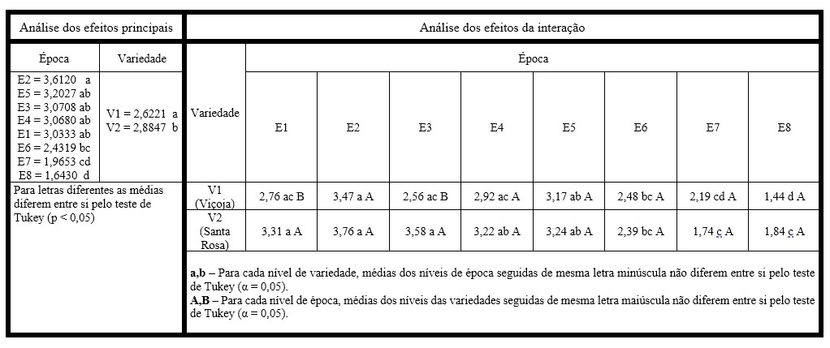

# Capítulo 11: Experimentos em faixas (“Split Block”)

## Exemplo 11.2 (Pág. 297)

Para exemplificar a obtenção da análise de variância de um experimento em faixas, vamos utilizar os dados de teor de potássio no solo (K), apresentados por Marcelo (2007). O experimento foi instalado em 3 blocos, com dois fatores dispostos em faixas. Os fatores estudados foram:  
A - Culturas de verão  
B - Culturas de inverno

Foram estudados os seguintes níveis do fator A:

A<sub>1</sub> = Rotaçao SM (Soja/milho)  
A<sub>2</sub> = Rotação AFA (Arroz/feijão/algodão)  
A<sub>3</sub> = Milho  
A<sub>4</sub> = Soja

Os níveis do fator B foram os seguintes:

B<sub>1</sub> = Milho  
B<sub>2</sub> = Girassol  
B<sub>3</sub> = Nabo forrageiro  
B<sub>4</sub> = Milheto  
B<sub>5</sub> = Guandu  
B<sub>6</sub> = Sorgo  
B<sub>7</sub> = Crotalária

Os dados obtidos do teor de potássio no solo (K) são apresentados no quadro a seguir:

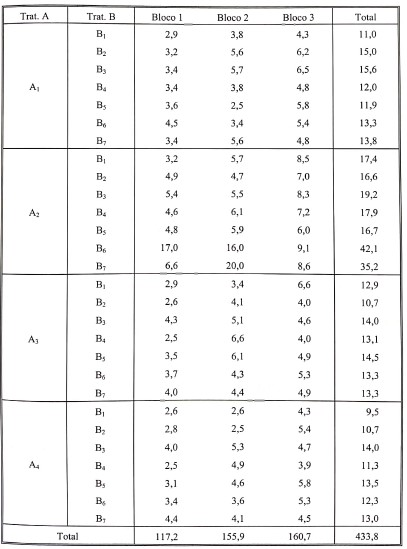

### Carregar os dados

Carregar os dados a partir do link.

```r
dados11_2 = read.csv("https://raw.githubusercontent.com/genivaldomoreira/Analise_experimentos_agronomicos/main/Dados/exemplo11_2.csv", header = TRUE, sep = ";", dec = ".")
head(dados11_2) # exibir as primeiras linhas para conferir
```

```
##   fatorA fatorB  bloco teor
## 1     A1     B1 bloco1  2.9
## 2     A1     B1 bloco2  3.8
## 3     A1     B1 bloco3  4.3
## 4     A1     B2 bloco1  3.2
## 5     A1     B2 bloco2  5.6
## 6     A1     B2 bloco3  6.2
```

### Análise por meio do pacote **ExpDes** e **ExpDes.pt**

OBS: Caso deseje cosultar o comando a ser executado, depois de carregar o pacote, use `help("faixas")`

```r
library(ExpDes.pt)
library(ExpDes)
faixas(dados11_2$fatorA, dados11_2$fatorB,
       dados11_2$bloco, dados11_2$teor,
       quali = c(TRUE, TRUE), mcomp = "tukey",
       fac.names = c("Fator A", "Fator B"),
       sigT = 0.05, sigF = 0.05)
```

```
## ------------------------------------------------------------------------
## Legenda:
## FATOR 1 (parcela):  Fator A
## FATOR 2 (subparcela):  Fator B
## ------------------------------------------------------------------------
##
## ------------------------------------------------------------------------
## Quadro da analise de variancia
## ------------------------------------------------------------------------
##                 GL     SQ     QM      Fc  Pr(>Fc)
## Bloco            2  40.63 20.315  8.0029 0.020270 *
## Fator A          3 205.76 68.586 30.3609 0.000504 ***
## Erro a           6  13.55  2.259
## Fator B          6  69.45 11.575  2.9711 0.051262 .
## Erro b          12  46.75  3.896
## Fator A*Fator B 18 165.70  9.205  2.5455 0.008350 **
## Erro c          36 130.19  3.616
## Total           83 672.03
## ---
## Signif. codes:  0 '***' 0.001 '**' 0.01 '*' 0.05 '.' 0.1 ' ' 1
## ------------------------------------------------------------------------
## CV 1 = 29.10373 %
## CV 2 = 38.22032 %
## CV 3 = 36.82382 %
##
##
##
## Interacao significativa: desdobrando a interacao
## ------------------------------------------------------------------------
##
## Desdobrando  Fator A  dentro de cada nivel de  Fator B
## ------------------------------------------------------------------------
##                             GL         SQ        QM        Fc  valor.p
## Fator A : Fator B B1   3.00000  11.753333  3.917778  1.144712 0.342405
## Fator A : Fator B B2   3.00000   9.096667  3.032222  0.885967 0.456355
## Fator A : Fator B B3   3.00000   6.013333  2.004444  0.585667  0.62782
## Fator A : Fator B B4   3.00000   8.862500  2.954167  0.863161 0.467858
## Fator A : Fator B B5   3.00000   4.036667  1.345556   0.39315 0.758569
## Fator A : Fator B B6   3.00000 212.410000 70.803333 20.687608        0
## Fator A : Fator B B7   3.00000 119.282500 39.760833 11.617483  1.2e-05
```

[output cut: 135 more lines]

```
## ------------------------------------------------------------------------
##
##  Fator B dentro de Fator A A4
## ------------------------------------------------------------------------
## De acordo com o teste F, as medias desse fator sao estatisticamente iguais.
## ------------------------------------------------------------------------
##   Niveis   Medias
## 1     B1 3.166667
## 2     B2 3.566667
## 3     B3 4.666667
## 4     B4 3.766667
## 5     B5 4.500000
## 6     B6 4.100000
## 7     B7 4.333333
## ------------------------------------------------------------------------
```

#### Análise do efeito isolado do fator A

```r
fatorA11_2= dbc(dados11_2$fatorA, dados11_2$bloco, dados11_2$teor,
    quali = TRUE, mcomp = "tukey", nl = FALSE,
    hvar = "oneillmathews", sigT = 0.05, sigF = 0.05)
```

```
## ------------------------------------------------------------------------
## Quadro da analise de variancia
## ------------------------------------------------------------------------
##            GL     SQ     QM      Fc     Pr>Fc
## Tratamento  3 205.76 68.586 12.5684 0.0000009
## Bloco       2  40.63 20.315  3.7228 0.0285619
## Residuo    78 425.65  5.457
## Total      83 672.03
## ------------------------------------------------------------------------
## CV = 45.23 %
##
## ------------------------------------------------------------------------
## Teste de normalidade dos residuos
## valor-p:  5.673292e-12
## ATENCAO: a 5% de significancia, os residuos nao podem ser considerados normais!
## ------------------------------------------------------------------------
##
## ------------------------------------------------------------------------
## Teste de homogeneidade de variancia
## valor-p:  1
## De acordo com o teste de oneillmathews a 5% de significancia, as variancias podem ser consideradas homogeneas.
## ------------------------------------------------------------------------
##
## Teste de Tukey
## ------------------------------------------------------------------------
## Grupos Tratamentos Medias
## a     A2      7.861905
##  b    A1      4.409524
##  b    A3      4.371429
##  b    A4      4.014286
## ------------------------------------------------------------------------
```

#### Análise do efeito isolado do fator B

```r
dbc(dados11_2$fatorB, dados11_2$bloco, dados11_2$teor,
    quali = TRUE, mcomp = "tukey", nl = FALSE,
    hvar = "oneillmathews", sigT = 0.05, sigF = 0.05)
```

```
## ------------------------------------------------------------------------
## Quadro da analise de variancia
## ------------------------------------------------------------------------
##            GL     SQ      QM     Fc    Pr>Fc
## Tratamento  6  69.45 11.5752 1.5449 0.175363
## Bloco       2  40.63 20.3154 2.7114 0.072961
## Residuo    75 561.95  7.4927
## Total      83 672.03
## ------------------------------------------------------------------------
## CV = 53 %
##
## ------------------------------------------------------------------------
## Teste de normalidade dos residuos
## valor-p:  1.823998e-11
## ATENCAO: a 5% de significancia, os residuos nao podem ser considerados normais!
## ------------------------------------------------------------------------
##
## ------------------------------------------------------------------------
## Teste de homogeneidade de variancia
## valor-p:  0.9978024
## De acordo com o teste de oneillmathews a 5% de significancia, as variancias podem ser consideradas homogeneas.
## ------------------------------------------------------------------------
##
## De acordo com o teste F, as medias nao podem ser consideradas diferentes.
##   Niveis   Medias
## 1     B1 4.233333
## 2     B2 4.416667
## 3     B3 5.233333
## 4     B4 4.525000
## 5     B5 4.716667
## 6     B6 6.750000
## 7     B7 6.275000
## ------------------------------------------------------------------------
```

#### **OBS:** Compare os resultados com os apresentados nas páginas 303 e 311 do livro-texto.